# Practical Machine Learning - Prediction Assignment Writeup

fruzsi

23 February 2017

# Backround and goals

Using devices such as Jawbone Up, Nike FuelBand, and Fitbit it is now possible to collect a large amount of data about personal activity relatively inexpensively. These type of devices are part of the quantified self movement - a group of enthusiasts who take measurements about themselves regularly to improve their health, to find patterns in their behavior, or because they are tech geeks. One thing that people regularly do is quantify how much of a particular activity they do, but they rarely quantify how well they do it. In this project, your goal will be to use data from accelerometers on the belt, forearm, arm, and dumbell of 6 participants. They were asked to perform barbell lifts correctly and incorrectly in 5 different ways.

#### Data source: http://groupware.les.inf.puc-rio.br/har

*This project is part of an assignment for Practical Machine Learning, Data Science specialisation, Coursera.*

## Environment and parameter settings

libraries and seed for (pseudo)randomizations (this latter is to ensure reproducibiliy of the models)

```r
library(plyr)         # has to be loaded before dplyr
library(dplyr)
library(knitr)
library(caret)
library(rpart)
library(rpart.plot)
library(rattle)
library(randomForest)
set.seed(35)
```

data source

```r
train.source <-
    "http://d396qusza40orc.cloudfront.net/predmachlearn/pml-training.csv"
test.source  <-
    "http://d396qusza40orc.cloudfront.net/predmachlearn/pml-testing.csv"
```

## Data acquisition and preparation

Download data sets and have a look at dimensions

```r
train <- read.csv(url(train.source))
testing  <- read.csv(url(test.source))
# look at data dimensions and factor names
dim(train)
```

```
## [1] 19622   160
```

```r
names(train)
```

```
##   [1] "X"                        "user_name"
##   [3] "raw_timestamp_part_1"     "raw_timestamp_part_2"
##   [5] "cvtd_timestamp"           "new_window"
##   [7] "num_window"               "roll_belt"
##   [9] "pitch_belt"               "yaw_belt"
##  [11] "total_accel_belt"         "kurtosis_roll_belt"
##  [13] "kurtosis_picth_belt"      "kurtosis_yaw_belt"
##  [15] "skewness_roll_belt"       "skewness_roll_belt.1"
##  [17] "skewness_yaw_belt"        "max_roll_belt"
##  [19] "max_picth_belt"           "max_yaw_belt"
##  [21] "min_roll_belt"            "min_pitch_belt"
##  [23] "min_yaw_belt"             "amplitude_roll_belt"
##  [25] "amplitude_pitch_belt"     "amplitude_yaw_belt"
##  [27] "var_total_accel_belt"     "avg_roll_belt"
##  [29] "stddev_roll_belt"         "var_roll_belt"
```

[output cut: 65 more lines]

The first few variables’ names suggest that they are volunteer IDs and timestamps. These (ideally) should not have an impact on classifying their activities so we are going to delete them from the data

```r
# remove ID and timestamp variables
train <- train[,-(1:5)]
```

Next step is to create a training and testing partition in our test data. We will train our models with the train partition and use the test partition to evaluate the models. Then, the best performing model (measured by accuracy in this case) will be used to predict the new items provided in the testing dataset.

```r
# create a train/ test set within the training data
trainslpit  <- createDataPartition(train$classe, p=0.7, list=FALSE)
train.train <- train[trainslpit, ]
train.test  <- train[-trainslpit, ]
```

Clean data: *a) remove variables with too much missing data (95% < NAs) and* b) remove variables with too low variance - these won’t add much into explaining the variability in the outcome variable

```r
# a) remove variables where majority of values are missing (95%)
misses   <- sapply(train.train, function(x) mean(is.na(x))) > 0.95
train.train <- train.train[, misses==F]
train.test  <- train.test[, misses==F]
dim(train.train)
```

```
## [1] 13737    88
```

```r
# remove variables with Nearly Zero Variance (NZV)
nzv <- nearZeroVar(train.train)
train.train <- train.train[, -nzv]
train.test  <- train.test[, -nzv]
dim(train.train)
```

```
## [1] 13737    54
```

# Model building

We will create two models - 1) Random forest, 2) Generalised Boosting Model. (These are the ‘favourite’ types in use)

## 1) Random Forest Model

Training with cross-validation

```r
# crossvalidation set
cvset <- trainControl(method="cv", number=5, verboseIter=F)
# model fit
rfmodel <- train(classe ~ ., data=train.train, method="rf",
                 trControl=cvset)
# the model
rfmodel$finalModel
```

```
##
## Call:
##  randomForest(x = x, y = y, mtry = param$mtry)
##                Type of random forest: classification
##                      Number of trees: 500
## No. of variables tried at each split: 27
##
##         OOB estimate of  error rate: 0.26%
## Confusion matrix:
##      A    B    C    D    E  class.error
## A 3905    1    0    0    0 0.0002560164
## B   10 2644    4    0    0 0.0052671181
## C    0    6 2390    0    0 0.0025041736
## D    0    1    7 2243    1 0.0039964476
## E    0    2    0    4 2519 0.0023762376
```

Now we will carry out the testing of the model on the test data partition. Calculate confusion matrix, accuracy, and out-of-sample error, that is the 1-accuracy. Out-of-sample error is the error in the prediction using the model on data that is not the training data the model was originally used to build.

```r
# prediction on test set, and evaluation (accuracy)
rfpredict <- predict(rfmodel, newdata=train.test)
confmatrix <- confusionMatrix(rfpredict, train.test$classe)
# accuracy
print(paste('accuracy:',as.character(confmatrix$overall['Accuracy'])))
```

```
## [1] "accuracy: 0.998810535259133"
```

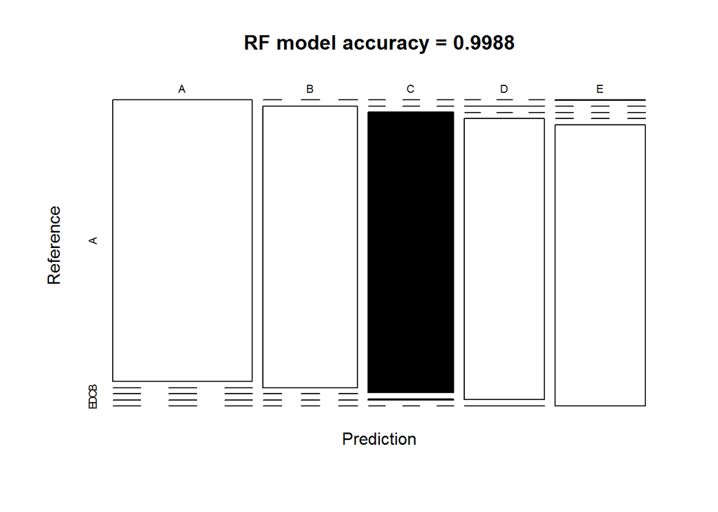

```r
# plot confusion matrix
plot(confmatrix$table, col = confmatrix$byClass,
     main = paste("RF model accuracy =",
                  round(confmatrix$overall['Accuracy'], 4)))
```

```r
# error (out-of-sample)
print(paste('out of sample error:',as.character(1-confmatrix$overall['Accuracy'])))
```

```
## [1] "out of sample error: 0.00118946474086656"
```

## 2) Generalised Boost Model

Training with cross-validation

```r
# crossvalidation set
cvset <- trainControl(method = "repeatedcv", number = 5, repeats = 1)
# model fit
gbmmodel  <- train(classe ~ ., data=train.train, method = "gbm",
                    trControl = cvset, verbose = F)
# 'le model
gbmmodel$finalModel
```

```
## A gradient boosted model with multinomial loss function.
## 150 iterations were performed.
## There were 53 predictors of which 42 had non-zero influence.
```

As above, we will carry out the testing of this GBM on the test data partition.

```r
# prediction on test set, and evaluation (accuracy, and out of sample error)
gbmpredict <- predict(gbmmodel, newdata=train.test)
confmatrix <- confusionMatrix(gbmpredict, train.test$classe)
# accuracy
print(paste('accuracy:',as.character(confmatrix$overall['Accuracy'])))
```

```
## [1] "accuracy: 0.98606627017842"
```

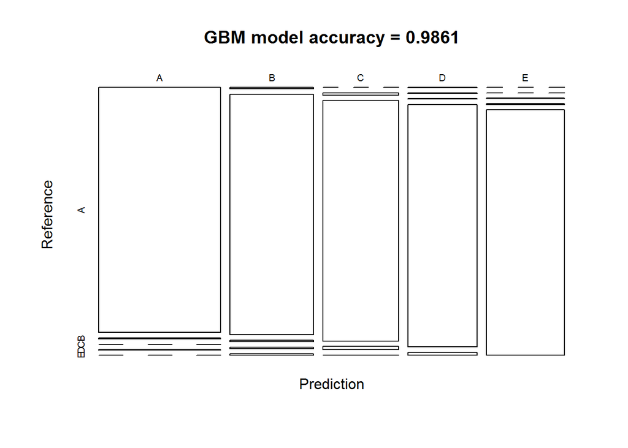

```r
# plot confusion matrix
plot(confmatrix$table, col = confmatrix$byClass,
     main = paste("GBM model accuracy =",
                  round(confmatrix$overall['Accuracy'], 4)))
```

```r
# error (out-of-sample)
print(paste('out of sample error:',as.character(1-confmatrix$overall['Accuracy'])))
```

```
## [1] "out of sample error: 0.0139337298215803"
```

# Model application - prediction of activity type based on new parameters

We choose Random Forest for now, since it had higher prediction accuracy on its test data set (GBM was also quite close, and both models were quite strong predictors for their test data. Furter options would include combining these two models but it is perhaps not necessary here)

```r
test.prediction <- predict(rfmodel, newdata=testing)
# predictions:
test.prediction
```

```
##  [1] B A B A A E D B A A B C B A E E A B B B
## Levels: A B C D E
```